# Missing Data and Imputation

Author

Tharun Teja Gandham & Mourya Rai Papolu (Advisor: Dr. Cohen)

Published

April 14, 2025

Slides: slides.html ()

## Introduction

Across healthcare, social sciences and finance sectors missing data continues as an extensive problem because it creates biased outcomes and reduces research reliability and weakens research conclusions unless appropriate data handling methods are used (Salgado et al. 2016). The Electronic Health Records (EHR) dataset faces high vulnerability to missing data from technological breakdowns as well as human mistakes and data loss incidents. In various fields missing data originates from survey non-responses and equipment failures as well as data entry errors (Alwateer et al. 2024). Improper handling of missing data leads to severe consequences on the quality of research findings and decision-making processes particularly when analyzing clinical epidemiology and structured datasets.

The solution for this issue requires researchers to implement imputation techniques that provide estimated values for missing data points. Various imputation methods exist which include basic methods like mean substitution and advanced techniques using multiple imputation along with machine learning models. The selection of a method for imputation requires knowledge of the missing data pattern because it can be MCAR or MAR or MNAR. Mean imputation and listwise deletion remain straightforward to use yet they produce biases or overlook missing value uncertainty (Pedersen et al. 2017).Multiple imputation and K-Nearest Neighbors (KNN) and Random Forests machine learning models effectively manage complex datasets that have high missingness levels and non-linear relationships. Proper evaluation procedures must be conducted because these techniques need to balance both computational efficiency and accuracy levels.

The selection of imputation methods relies on both the dataset characteristics and the nature of missing data according to recent research findings. Research on 58 articles demonstrates traditional methods work best for data sets with straightforward missingness patterns but deep learning and hybrid models deliver superior results for complex data patterns. The social science field demonstrates that semi-parametric techniques including predictive mean matching with hot deck imputation deliver superior results compared to fully parametric methods for item-nonresponse data according to (Durrant et al. 2005). The research emphasizes the requirement for imputation approaches which match the unique needs of datasets along with their associated research goals.

### Literature Review

Missing data is common problem in data science, which affects the accuracy and reliability of analyses across different domains. This section summarizes major findings from existing research on ‘missing data imputation’, which focus on old traditional and new advanced methods and their applications, limitations.

1. Mechanisms of Missing Data:

How missing data is dealt with in practice depends entirely on what type of missingness it has, so that it can be classified as Missing Completely at Random (MCAR), Missing at Random (MAR), or Not Missing at Random (NMAR). In terms of clinical research, MAR is a very common means of missing data, often being the result of careening into trees or equipment breaking (Salgado et al. 2016). Identifying these mechanisms is important for correctly chosen allocation mechanisms. (Lee and Raghunathan 2024) stress that robustness across time for data acquisition must be used to prevent missing data in clinical studies together with monitoring as close to real-time as possible.

2. Traditional Imputation Methods:

Traditional methods such as mean substitution, regression imputation, and listwise deletion are simple, widely used, but also introduce bias or reduce statistical power. When mean substitution is performed, the original distribution of data is disrupted as one point is substituting every missing figure. It may be biased or not exceed thoroughness in cases where people can participate for complete information and which doesn’t require objectives. Sample size is reduced by listwise deletion hence leading to loss of statistical power (Alwateer et al. 2024). However, traditional methods still remain popular because of their simplicity of implementation and the manner in which they focus on bias rather than noise in data. (Yadav, Vishwakarma, and Sharma 2024) offer a comprehensive overview of these methods, pointing out that their main employment is low-dimensional data sets with simple missing patterns

3. Advanced Imputation Techniques:

Multiple imputation alongside machine learning and deep learning models demonstrate effectiveness when dealing with complex datasets having substantial amounts of missing data. Referred to by Little & Rubin (Yadav, Vishwakarma, and Sharma 2024) Multiple Imputation by Chained Equations (MICE) produces numerous datasets with imputed values which it then combines to deal with uncertainty in clinical research. The algorithm MissForest uses Random Forests to analyze mixed-type data while showing reliable results across MCAR, MAR, and MNAR data conditions according to (Stekhoven and Bühlmann 2012). The application of K-Nearest Neighbors (KNN) and Random Forests along with Autoencoders in machine learning demonstrates exceptional ability to analyze high-dimensional data structures with non-linear relationships according to (Karim and Islam 2024) thoroughly examines state-of-the-art methods which show excellent performance in processing complex multi-dimensional data (2024).

4. Applications and Challenges:

With structured data sets suffering from missingness and such errors, method of imputation has a big effect on the quality of the analysis. While imputing traditionaly works fine for data with simple missingness patterns, a systematic review of 58 articles shows that in more complex casus only advanced technologies such as deep learning are better able to handle this issue out (Afkanpour, Hosseinzadeh, and Tabesh 2024). But challenges remain, including the computational workload and lack of widely accepted methods for assessing results, which act as barriers to employing these new standards (Alwateer et al. 2024). Discussing the potential and pitfalls of m method of imputation for datasets their epidemiological research is based on (Sterne et al. 2009) particularly emphasize model specification and the need for sensictivity analysis to see if results are being biased in any one direction.

5. Semi-Parametric and Hybrid Approaches:

The hybrid approach is increasingly and becoming popular with researchers Just see the number of references to it on Google Scholar this year Outperforming fully parametric approaches in social science research, semi-parametric methods such as predictive mean matching and hot deck imputation show great potential for item-nonresponse data (Durrant et al. 2005). Hybrid methods, combining traditional methods and machine learning, also deliver satisfactory results in increasing imputation accuracies without increasing computational time at all (Afkanpour, Hosseinzadeh, and Tabesh 2024).It is noted by (Lee and Raghunathan 2024) that in clinical research settings, hybrid ones may well operate. Whether because a better preventive device with more sophisticated analytics yields even worse data quality than ever before; or due to some other double-combining of tools and methods, weightless chances must not be missed out on because of their particular novelty (Farhangfar, Kurgan, and Pedrycz 2007).

## Methods

#### 1.Mean and Mode Imputation

Mean and mode imputation are simple methods that replace missing values with the average (for numerical data) or most common value (for categorical data) of the observed values.

Imputation with mean involves substituting missing values with the arithmetic mean calculated from observed values.

This method replaces missing values by using the mode which represents the most frequent value present in observed data points.

The implementation of these methods remains straightforward yet data distortion may occur when missing values exceed a certain threshold (Pedersen et al. 2017) (Afkanpour, Hosseinzadeh, and Tabesh 2024).

The mean imputation formula is:

$$\hat{x}_i = \bar{x} = \frac{1}{n} \sum_{j=1}^{n} x_j$$

where x^i is the imputed value, xˉ is the mean of the observed values, n is the number of observed values, and xj is the j-th observed value (Pedersen et al. 2017) (Afkanpour, Hosseinzadeh, and Tabesh 2024).

Mode Imputation:
$$\hat{x}_i=mode(x)$$
where mode(x)mode(x) is the most frequently occurring value in the dataset (Pedersen et al. 2017) (Afkanpour, Hosseinzadeh, and Tabesh 2024).

#### 2.Regression Imputation

A regression model enables regression imputation to predict missing values by analyzing the connections between other variables in the dataset. For example:

The Age column’s missing values can be predicted with the help of Pclass and Fare variables.

The method requires linear variable relationships as its foundation but provides advanced handling compared to mean/mode imputation (Little & Rubin, 2002; (Farhangfar, Kurgan, and Pedrycz 2007).

Regression Model: The regression imputation formula is:

$$\begin{align}
\hat{x}_i &= \beta_0 + \beta_1 x_1 + \beta_2 x_2 + \dots + \beta_p x_p + \epsilon_i \\
\text{where} \quad \beta_0 &= \text{intercept}, \quad \beta_1, \dots, \beta_p = \text{coefficients}
\end{align}$$
where x^i is the predicted value, β0,β1,…,βp are the regression coefficients, and ϵi is the error term (Yadav, Vishwakarma, and Sharma 2024); (Little and Rubin 2019).

#### 3.K-Nearest Neighbors (KNN) Imputation

K-Nearest Neighbors (KNN) is a machine learning algorithm used for both classification and regression tasks. In the context of missing data imputation:

KNN finds the K most similar rows (neighbors) in the dataset based on the values of other features.

It then uses the values from these neighbors to estimate the missing values. For each row with a missing value, KNN looks at the other features (columns) in the dataset.It calculates the distance (e.g., Euclidean distance) between the row with the missing value and all other rows.

It selects the K nearest neighbors (rows) that are most similar based on the distance.

The algorithm obtains the average measurement point for numerical data and most frequent value for categorical data from the k nearest neighbors.

KNN Formula: The KNN imputation formula is:

$$\hat{x}_i = \frac{1}{k} \sum_{j \in N_k(i)} x_j \label{eq:knn}$$
k Specifies the number of nearest neighbors to use.

#### 4.Multiple Imputation by Chained Equations (MICE)

MICE serves as a popular method for missing data management through its creation of numerous complete versions of original datasets. MICE proves effective in dealing with complex missing data patterns provided data follow the MAR assumption. The following description of MICE features a detailed analysis supported by references from Pedersen et al. (2017).

How MICE Works

- Initialization:

MICE starts by filling in the missing values with initial guesses (e.g., mean, median, or random values). These are temporary placeholders and will be refined in subsequent steps (Pedersen et al., 2017).

- Iterative Imputation:

Each variable with missing data within MICE undergoes regression model analysis to generate predicted values by using other dataset variables. A model selection depends on the variable type for regression analysis. Linear regression for numeric variables. Logistic regression for binary categorical variables. Multinomial regression for multi-class categorical variables (Pedersen et al., 2017). The imputation process runs repeatedly while updating missing value predictions during each cycle until prediction changes reach an unnoticeable point.

- Multiple Imputed Datasets:

The MICE method creates five to ten datasets which represent diverse plausible alternatives for missing data values. The method represents the unknown nature of missing data values (Pedersen et al., 2017).

- Combining Results:

Each data set created through MICE receives separate analysis for the study interest such as logistic regression. Combines the results from these datasets to provide unbiased and valid estimates of associations according to Pedersen et al. (2017).

- For now we are proceeding with mean/mode , regression and knn imputations.

## Data Exploration and Visualization

- Describe your data sources and collection process.

  (https://www.kaggle.com/c/titanic/data)

The Titanic dataset from Kaggle is a widely used dataset for data analysis and machine learning projects. It contains information about the passengers aboard the Titanic, including whether they survived or not. The dataset includes features such as:

- PassengerId: A unique identifier for each passenger.
- Survived: Whether the passenger survived (1) or not (0).
- Pclass: The ticket class (1st, 2nd, or 3rd), which is a proxy for socio-economic status.
- Name: The name of the passenger.
- Sex: The gender of the passenger (male or female).
- Age: The age of the passenger.
- SibSp: The number of siblings/spouses aboard the Titanic.
- Parch: The number of parents/children aboard the Titanic.
- Ticket: The ticket number.
- Fare: The fare paid for the ticket.
- Cabin: The cabin number (many missing values).
- Embarked: The port of embarkation (C = Cherbourg, Q = Queenstown, S = Southampton).

```r
# Set CRAN mirror
options(repos = c(CRAN = "https://cloud.r-project.org"))

# Install and load ggplot2
if (!require(ggplot2)) install.packages("ggplot2")
library(ggplot2)

# Install and load naniar
if (!require(naniar)) install.packages("naniar")
library(naniar)
```

```r
library(dplyr)
#titanic dataset
train<-read.csv("train.csv")
# Replace empty strings with NA in specific columns
train <- train %>%
  mutate(
    Cabin = na_if(Cabin, ""),
    Embarked = na_if(Embarked, "")
  )
summary(train)
```

```
  PassengerId       Survived          Pclass          Name
 Min.   :  1.0   Min.   :0.0000   Min.   :1.000   Length:891
 1st Qu.:223.5   1st Qu.:0.0000   1st Qu.:2.000   Class :character
 Median :446.0   Median :0.0000   Median :3.000   Mode  :character
 Mean   :446.0   Mean   :0.3838   Mean   :2.309
 3rd Qu.:668.5   3rd Qu.:1.0000   3rd Qu.:3.000
 Max.   :891.0   Max.   :1.0000   Max.   :3.000

     Sex                 Age            SibSp           Parch
 Length:891         Min.   : 0.42   Min.   :0.000   Min.   :0.0000
 Class :character   1st Qu.:20.12   1st Qu.:0.000   1st Qu.:0.0000
 Mode  :character   Median :28.00   Median :0.000   Median :0.0000
                    Mean   :29.70   Mean   :0.523   Mean   :0.3816
                    3rd Qu.:38.00   3rd Qu.:1.000   3rd Qu.:0.0000
                    Max.   :80.00   Max.   :8.000   Max.   :6.0000
                    NA's   :177
    Ticket               Fare           Cabin             Embarked
 Length:891         Min.   :  0.00   Length:891         Length:891
 Class :character   1st Qu.:  7.91   Class :character   Class :character
 Mode  :character   Median : 14.45   Mode  :character   Mode  :character
                    Mean   : 32.20
                    3rd Qu.: 31.00
                    Max.   :512.33
```

```r
#missing values column wise
colSums(is.na(train))
```

```
PassengerId    Survived      Pclass        Name         Sex         Age
          0           0           0           0           0         177
      SibSp       Parch      Ticket        Fare       Cabin    Embarked
          0           0           0           0         687           2
```

- Age column has 177 missing values
- Cabin column has large number of missing values 687
- Similarly embarked column has 2 missing values.

##### Unexpected patterns or anomalies.

```r
# creating a data frame to show the missing values percentage
missing_data<-data.frame(
  column_name=names(train),
  missing_val=colSums(is.na(train)),
  missing_percent=colSums(is.na(train)/nrow(train))*100
)

print(missing_data)
```

```
            column_name missing_val missing_percent
PassengerId PassengerId           0       0.0000000
Survived       Survived           0       0.0000000
Pclass           Pclass           0       0.0000000
Name               Name           0       0.0000000
Sex                 Sex           0       0.0000000
Age                 Age         177      19.8653199
SibSp             SibSp           0       0.0000000
Parch             Parch           0       0.0000000
Ticket           Ticket           0       0.0000000
Fare               Fare           0       0.0000000
Cabin             Cabin         687      77.1043771
Embarked       Embarked           2       0.2244669
```

The Titanic dataset has missing values primarily in the Age and Cabin columns, with 177 (19.87%) and 687 (77.10%) missing entries, respectively. The Embarked column has only 2 (0.22%) missing values, which is negligible. All other columns, such as PassengerId, Survived, and Sex, are complete with no missing data, making them reliable for analysis.

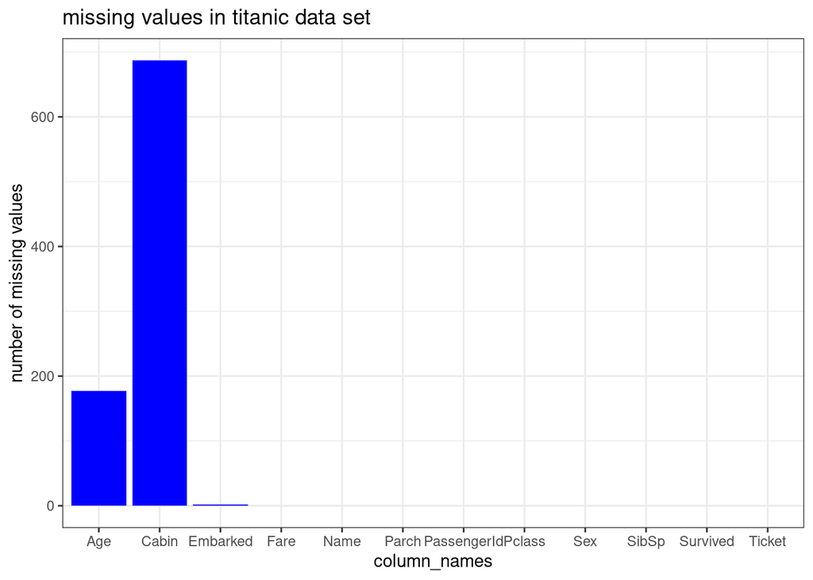

```r
#visualization of my data set through ggplot
ggplot(missing_data,aes(x=column_name,y=missing_val))+
  geom_bar(stat="identity",fill="blue")+
  labs(title="missing values in titanic data set", x="column_names", y="number of missing values")+
  theme_bw()
```

- each column and their missingness compared in bar chart, cabin column has highest number of missing values.

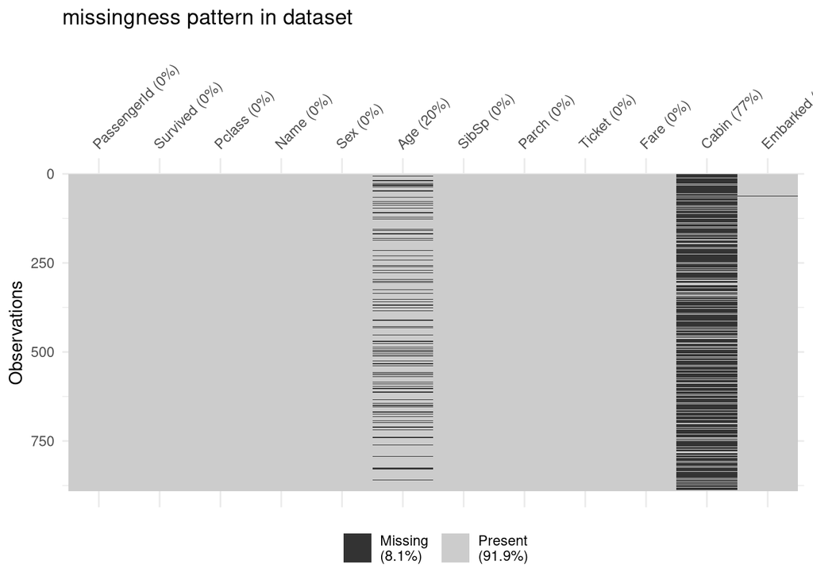

```r
vis_miss(train)+
  labs(title="missingness pattern in dataset")
```

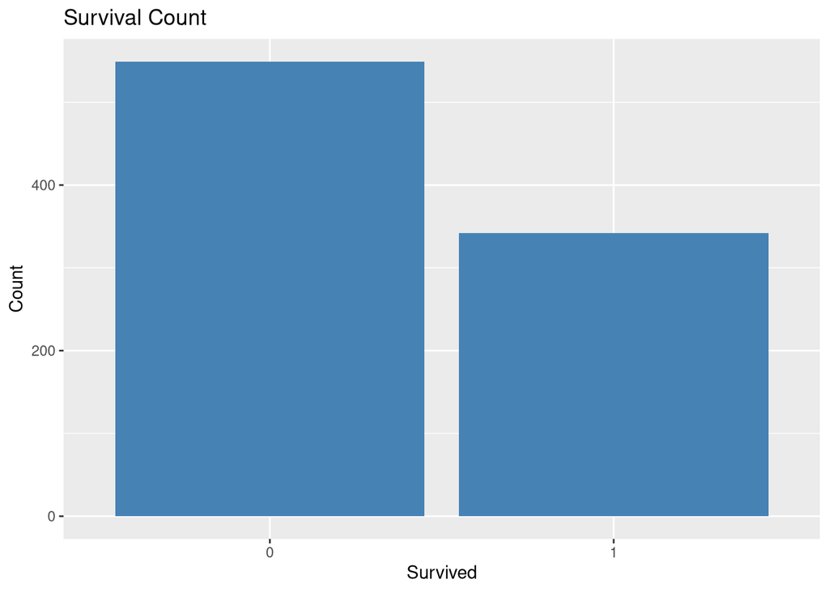

```r
#Whether the passenger survived (1) or not (0)
ggplot(train, aes(x = factor(Survived))) +
  geom_bar(fill = "steelblue") +
  labs(title = "Survival Count", x = "Survived", y = "Count")
```

The plot shows that fewer passengers survived . This depiction emphasizes the survival rate imbalance in the data since it strongly affects both analytical processes and model predictions of survival estimates.

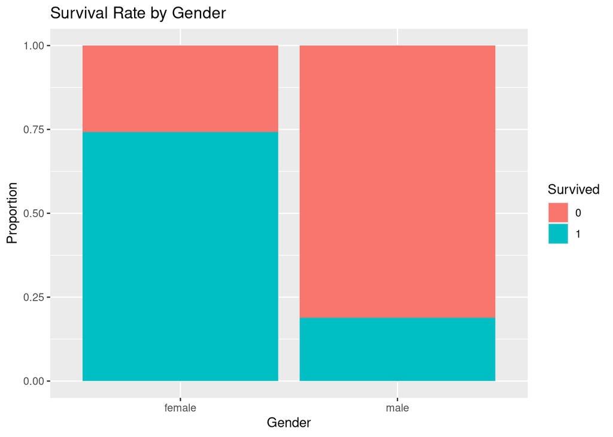

```r
ggplot(train, aes(x = Sex, fill = factor(Survived))) +
  geom_bar(position = "fill") +
  labs(title = "Survival Rate by Gender", x = "Gender", y = "Proportion", fill = "Survived")
```

- we can see that more female passengers are survived than male passengers from total number of passengers.

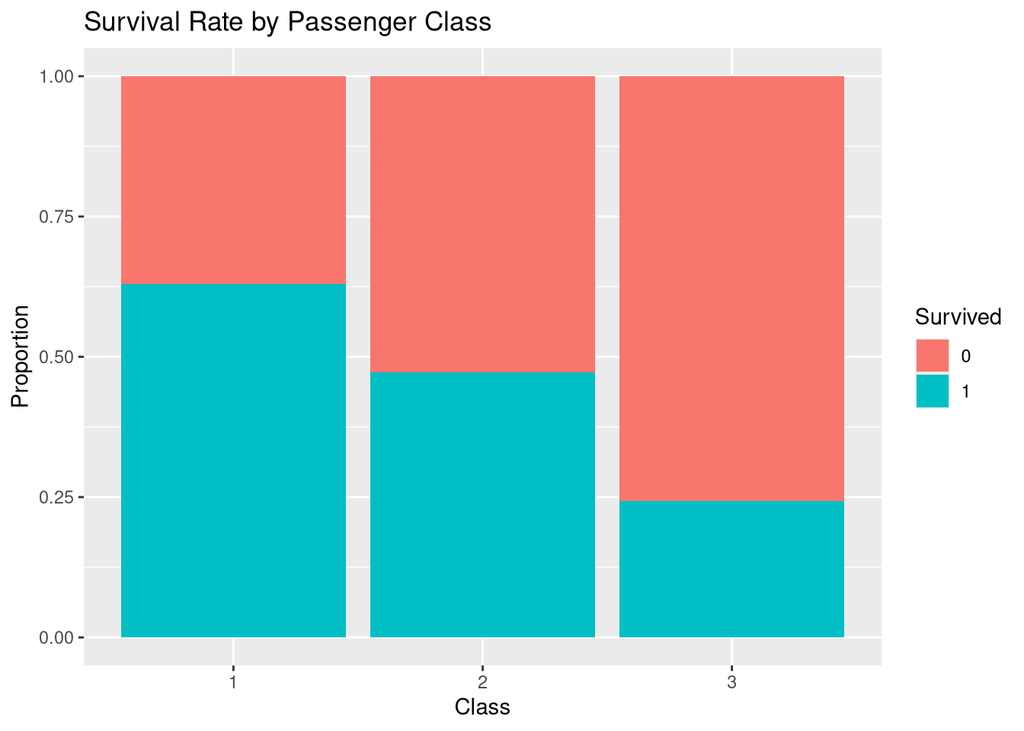

```r
ggplot(train, aes(x = factor(Pclass), fill = factor(Survived))) +
  geom_bar(position = "fill") +
  labs(title = "Survival Rate by Passenger Class", x = "Class", y = "Proportion", fill = "Survived")
```

The stacked bar chart illustrates the survival rate of passengers by class on the Titanic. First-class passengers had the highest proportion of survivors, followed by second class, while third-class passengers had the lowest survival rate. Notably, the majority of third-class passengers did not survive, highlighting the disparity in survival chances based on socioeconomic status. This suggests that higher-class passengers likely had better access to lifeboats or evacuation assistance. The visualization underscores how passenger class played a significant role in determining survival during the disaster.

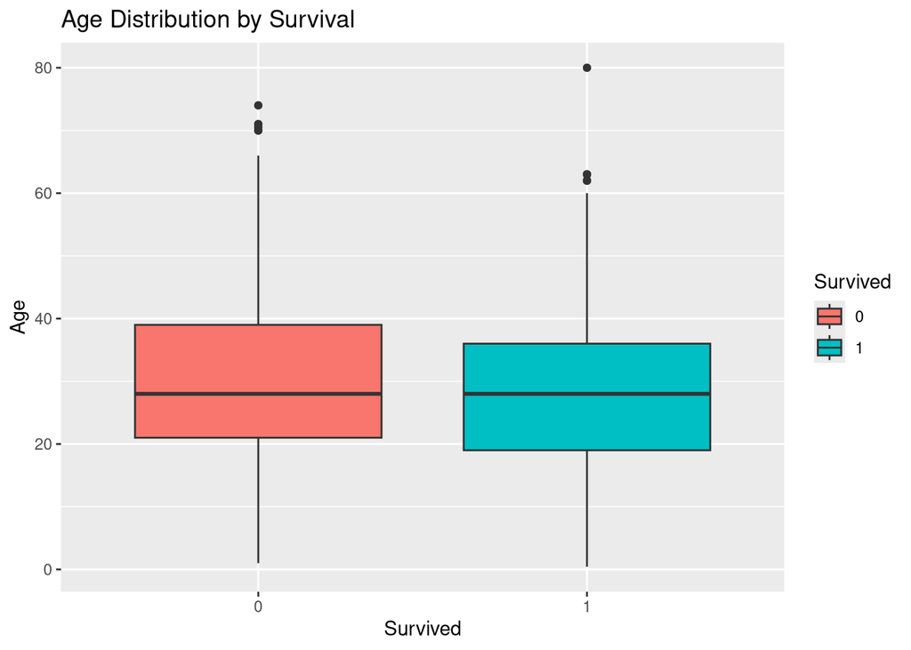

```r
ggplot(train, aes(x = factor(Survived), y = Age, fill = factor(Survived))) +
  geom_boxplot() +
  labs(title = "Age Distribution by Survival", x = "Survived", y = "Age", fill = "Survived")
```

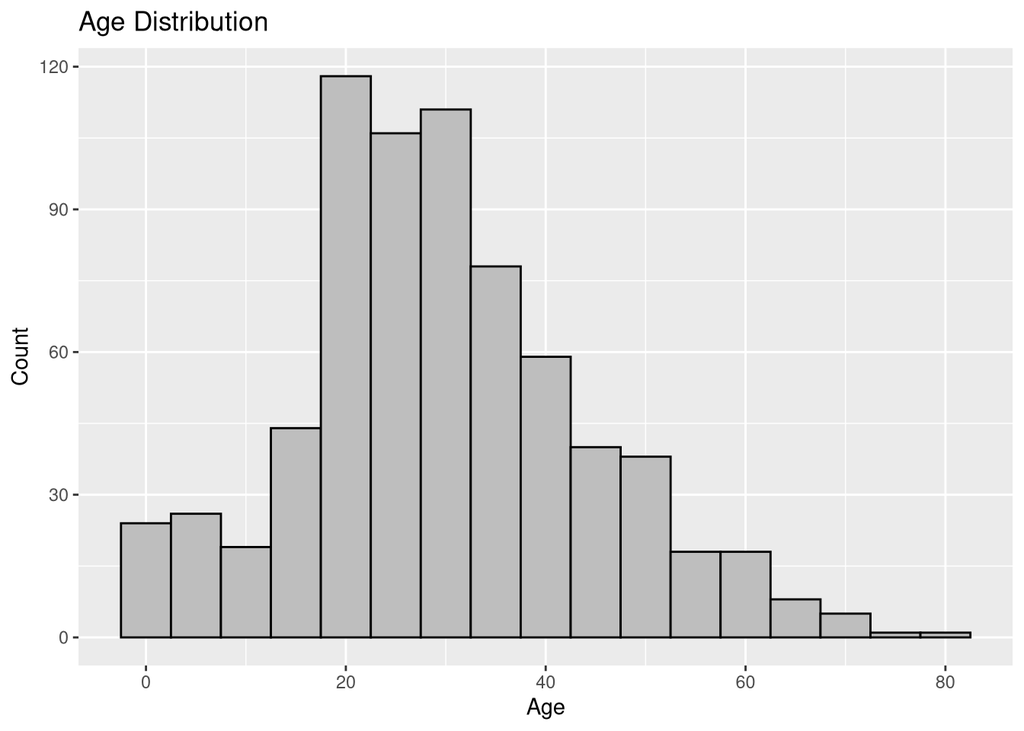

```r
# Age Distribution
ggplot(train, aes(x = Age)) +
  geom_histogram(binwidth = 5, fill = "gray", color = "black") +
  labs(title = "Age Distribution", x = "Age", y = "Count")
```

The histogram displays the distribution of passenger ages. The majority of passengers fall within the 20–40 age range, with a peak around the early twenties. A smaller number of passengers are younger children or older adults, with very few above 60. The distribution is right-skewed, indicating more younger passengers compared to older ones. This visualization helps understand the overall age demographics and can guide imputation strategies for missing age values.

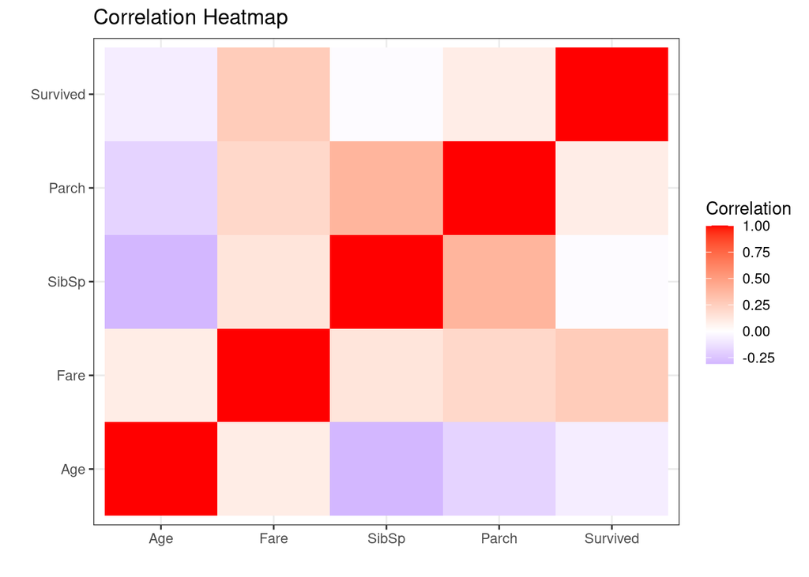

```r
library(reshape2)

# Select numeric columns
numeric_data <- train %>%
  select(Age, Fare, SibSp, Parch, Survived)

# Compute correlation matrix
cor_matrix <- cor(numeric_data, use = "complete.obs")

# Melt the correlation matrix for ggplot
melted_cor_matrix <- melt(cor_matrix)

# Plot heatmap
ggplot(melted_cor_matrix, aes(x = Var1, y = Var2, fill = value)) +
  geom_tile() +
  scale_fill_gradient2(low = "blue", high = "red", mid = "white", midpoint = 0) +
  labs(title = "Correlation Heatmap", x = "", y = "", fill = "Correlation") +
  theme_bw()
```

This correlation heatmap provides insights into relationships between key numerical variables in our dataset. Darker red indicates a strong positive correlation, while purple represents a negative correlation. For example, ‘Fare’ and ‘Survived’ show a positive correlation, suggesting passengers who paid higher fares had a higher survival rate. Identifying these relationships helps in understanding data patterns, which is crucial when handling missing values, as correlations can guide imputation strategies.

The Pearson correlation coefficient ($r$) measures the linear relationship between two variables, ranging from $-1$ to $+1$. It is computed as:
$$\begin{align}
r &= \frac{n(\sum XY) - (\sum X)(\sum Y)}{\sqrt{[n \sum X^2 - (\sum X)^2][n \sum Y^2 - (\sum Y)^2]}} \\
\text{where} \quad n &= \text{number of observations}, \\
X, Y &= \text{paired variables}, \\
\sum XY &= \text{sum of cross-products}, \\
\sum X, \sum Y &= \text{sums of individual variables}.
\end{align}$$

## Analysis and Results

#### Mean and Mode Imputation

```r
# copy of the original data set
train_imputed1<- train
```

```r
# Mean imputation for Age( numeric column)
mean_age <- mean(train_imputed1$Age, na.rm = TRUE) #(remove na while caluclating mean)
train_imputed1 <- train_imputed1 %>%
  mutate(Age = ifelse(is.na(Age), mean_age, Age))
```

```r
# Mode imputation replaces missing values in categorical columns (e.g., Embarked) with the mode (most frequent value) of the column.

# Mode imputation for Embarked
mode_embarked <- names(sort(table(train_imputed1$Embarked), decreasing = TRUE))[1]
train_imputed1 <- train_imputed1 %>%
  mutate(Embarked = ifelse(is.na(Embarked), mode_embarked, Embarked))

# Mode imputation for Cabin
mode_cabin <- names(sort(table(train_imputed1$Cabin), decreasing = TRUE))[1]
train_imputed1 <- train_imputed1 %>%
  mutate(Cabin = ifelse(is.na(Cabin), mode_cabin, Cabin))


colSums(is.na(train_imputed1))
```

```
PassengerId    Survived      Pclass        Name         Sex         Age
          0           0           0           0           0           0
      SibSp       Parch      Ticket        Fare       Cabin    Embarked
          0           0           0           0           0           0
```

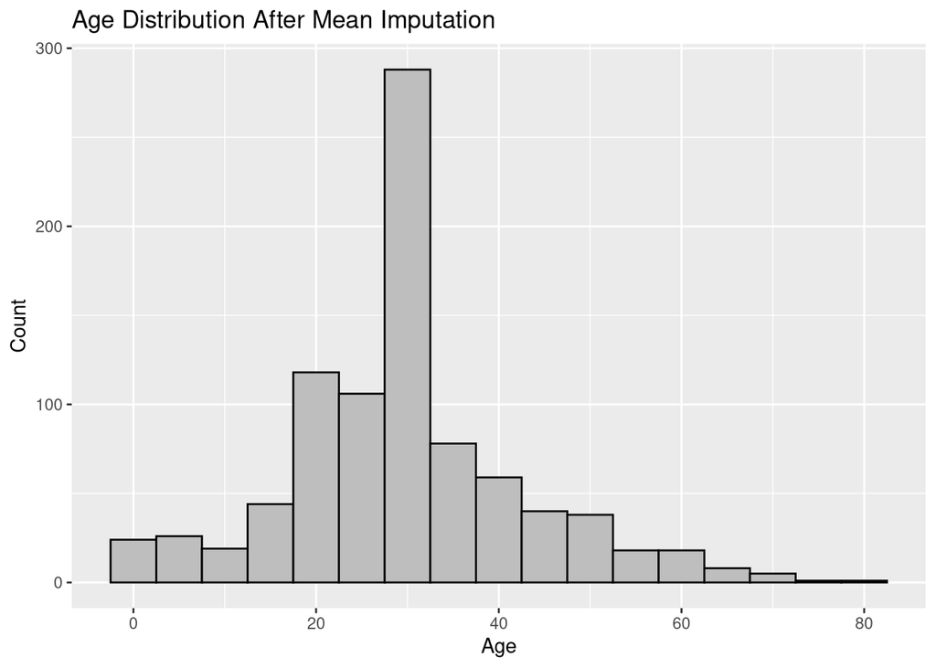

```r
#  Visualizing Age distribution after imputation
ggplot(train_imputed1, aes(x = Age)) +
  geom_histogram(binwidth = 5, fill = "gray", color = "black") +
  labs(title = "Age Distribution After Mean Imputation", x = "Age", y = "Count")
```

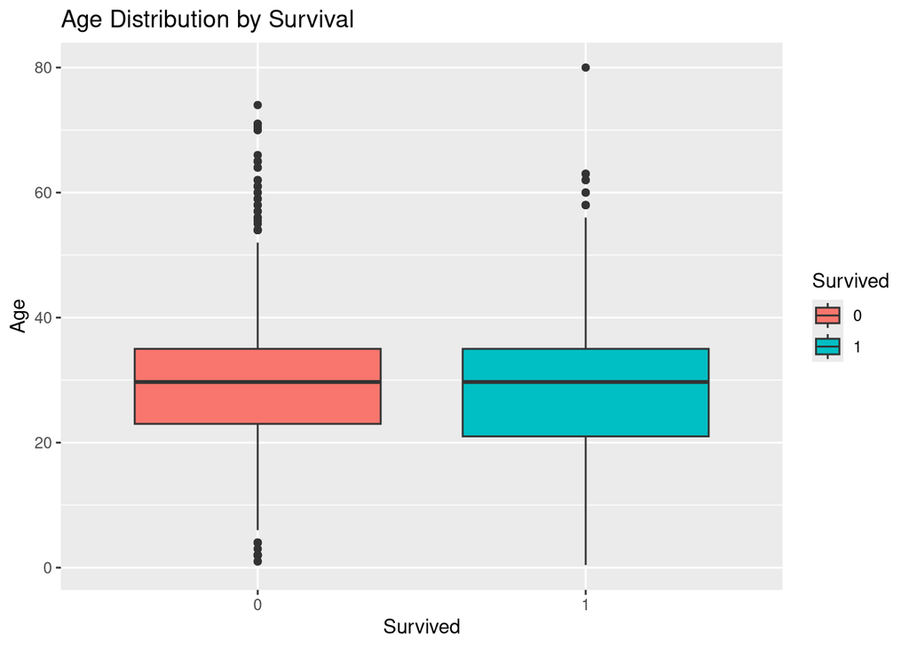

```r
ggplot(train_imputed1, aes(x = factor(Survived), y = Age, fill = factor(Survived))) +
  geom_boxplot() +
  labs(title = "Age Distribution by Survival", x = "Survived", y = "Age", fill = "Survived")
```

- After imputation, ages cluster sharply around 28–30, losing the original spread (20–40 years).
- This artificial spike may distort survival predictions, overemphasizing the imputed age.
- Results could be biased.

##### REGRESSION IMPUTATION

```r
#linear regression for age (numerical data)
train_regression<-train
# Fit the linear regression model
age_model <- lm(Age ~ Pclass + Sex + SibSp + Parch + Fare, data = train_regression)

# Identify rows with missing Age
missing_age <- is.na(train_regression$Age)

# Predict missing Age values
train_regression$Age[missing_age] <- predict(age_model, newdata = train_regression[missing_age, ])
```

```r
sum(is.na(train_regression$Embarked))
```

```
[1] 2
```

Since Embarked column has 3 categories: “C”, “Q”, “S” we are using Multinomial Logistic Regression for Embarked.

```r
library(nnet)

# Fit a multinomial logistic regression model for Embarked
embarked_model <- multinom(Embarked ~ Pclass + Sex + Age + SibSp + Parch + Fare,
                           data = train_regression)
missing_embarked <- is.na(train_regression$Embarked)

predicted_embarked <- predict(embarked_model, newdata = train_regression[missing_embarked, ], type = "class")

# Replace missing values with predicted values
train_regression$Embarked[missing_embarked] <- predicted_embarked
```

- Too Many Missing Values: 687 missing values out of 891 is a lot, and regression imputation might not work well due to the lack of sufficient data.
- The Cabin column has many unique categories (e.g., “G6”, “C103”, “C123”, etc.), making regression imputation computationally expensive and less reliable.
- So i am using mode imputation for this column.

```r
# Mode imputation for Cabin
mode_reg <- names(sort(table(train_regression$Cabin), decreasing = TRUE))[1]
train_regression <- train_regression %>%
  mutate(Cabin = ifelse(is.na(Cabin), mode_reg, Cabin))


colSums(is.na(train_regression))
```

```
PassengerId    Survived      Pclass        Name         Sex         Age
          0           0           0           0           0           0
      SibSp       Parch      Ticket        Fare       Cabin    Embarked
          0           0           0           0           0           0
```

using regression imputation techiniques i Replaced NA values .

##### KNN IMPUTATION

```r
# Load the VIM package
library(VIM)

# Perform KNN imputation
train_knn <- kNN(train, k = 5)


# Check missing values after imputation
colSums(is.na(train_knn))
```

```
    PassengerId        Survived          Pclass            Name             Sex
              0               0               0               0               0
            Age           SibSp           Parch          Ticket            Fare
              0               0               0               0               0
          Cabin        Embarked PassengerId_imp    Survived_imp      Pclass_imp
              0               0               0               0               0
       Name_imp         Sex_imp         Age_imp       SibSp_imp       Parch_imp
              0               0               0               0               0
     Ticket_imp        Fare_imp       Cabin_imp    Embarked_imp
              0               0               0               0
```

### Modeling and Results

#### Comparing Age distributions

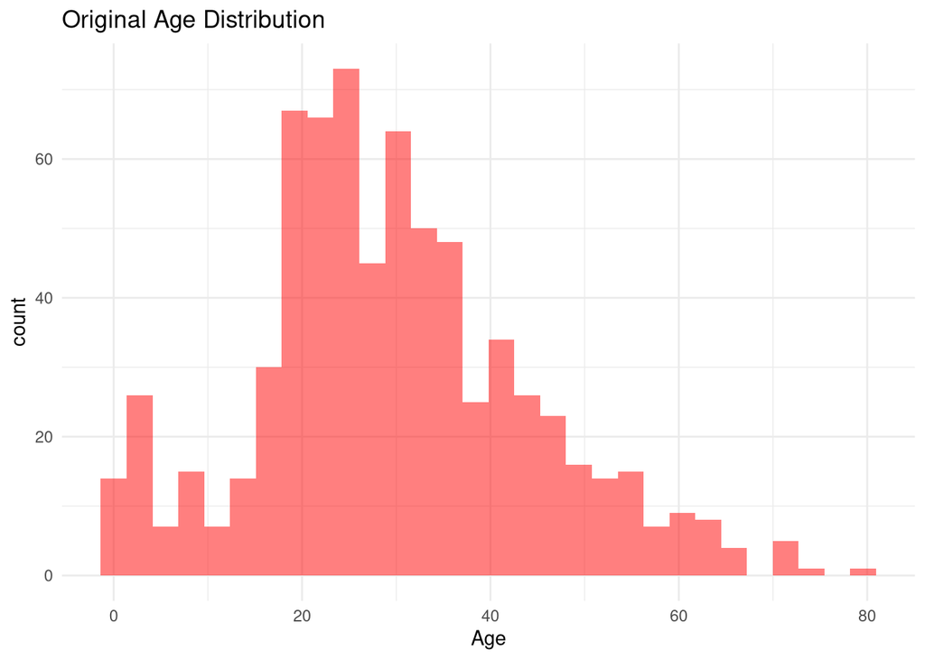

```r
library(ggplot2)


ggplot(train, aes(Age)) +
  geom_histogram(fill="red", alpha=0.5, bins=30) +
  ggtitle("Original Age Distribution") +
  theme_minimal()
```

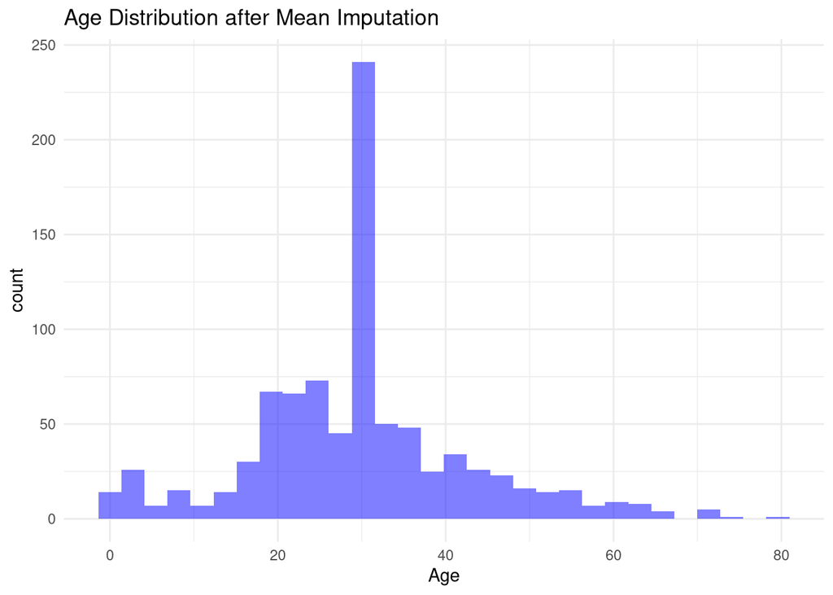

```r
ggplot(train_imputed1, aes(Age)) +
  geom_histogram(fill="blue", alpha=0.5, bins=30) +
  ggtitle("Age Distribution after Mean Imputation") +
  theme_minimal()
```

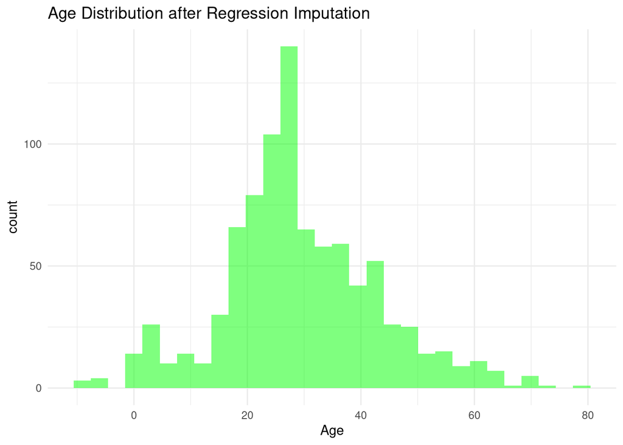

```r
ggplot(train_regression, aes(Age)) +
  geom_histogram(fill="green", alpha=0.5, bins=30) +
  ggtitle("Age Distribution after Regression Imputation") +
  theme_minimal()
```

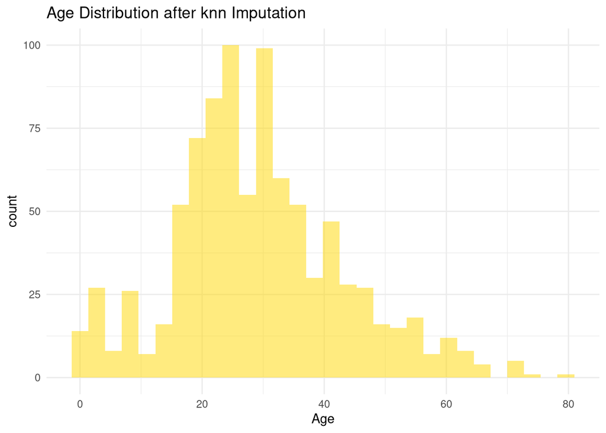

```r
ggplot(train_knn,aes(Age)) +
  geom_histogram(fill="gold",alpha=0.5, bins=30)+
  ggtitle("Age Distribution after knn Imputation") +
  theme_minimal()
```

What This Means: Mean imputation distorts the data by forcing all missing ages to be similar, while regression and KNN methods keep the natural variation we see in the original dataset. For accurate analysis, regression or KNN work better than simple mean replacement.

##### Model Performance

```r
model_1 <- Survived ~ Pclass + Sex + Age + SibSp + Parch + Fare + Embarked

# Train models on different imputed datasets
logit_mean <- glm(model_1, data = train_imputed1, family = "binomial")
logit_reg <- glm(model_1, data = train_regression, family = "binomial")
logit_knn <- glm(model_1, data = train_knn, family = "binomial")
```

```r
install.packages("caret", dependencies = TRUE)
library(caret)
```

```r
# Convert Survived column to factor (Required for confusionMatrix)
train_imputed1$Survived <- as.factor(train_imputed1$Survived)
train_regression$Survived <- as.factor(train_regression$Survived)
train_knn$Survived <- as.factor(train_knn$Survived)

# Get predictions (Convert probabilities to binary predictions: 1 if >0.5 else 0)
pred_mean <- ifelse(predict(logit_mean, type = "response") > 0.5, 1, 0)
pred_reg <- ifelse(predict(logit_reg, type = "response") > 0.5, 1, 0)
pred_knn <- ifelse(predict(logit_knn, type = "response") > 0.5, 1, 0)

# Convert predictions and actual values to factors for confusionMatrix()
pred_mean <- as.factor(pred_mean)
pred_reg <- as.factor(pred_reg)
pred_knn <- as.factor(pred_knn)

# Compute confusion matrices
conf_matrix_mean <- confusionMatrix(pred_mean, train_imputed1$Survived)
conf_matrix_reg <- confusionMatrix(pred_reg, train_regression$Survived)
conf_matrix_knn <- confusionMatrix(pred_knn, train_knn$Survived)

# Print accuracy for each model
cat("Accuracy with Mean/Mode Imputation:", conf_matrix_mean$overall['Accuracy'], "\n")
```

```
Accuracy with Mean/Mode Imputation: 0.8013468
```

```r
cat("Accuracy with Regression Imputation:", conf_matrix_reg$overall['Accuracy'], "\n")
```

```
Accuracy with Regression Imputation: 0.8080808
```

```r
cat("Accuracy with KNN Imputation:", conf_matrix_knn$overall['Accuracy'], "\n")
```

```
Accuracy with KNN Imputation: 0.8103255
```

- Results show that KNN imputation performed the best in terms of accuracy, followed by regression imputation, and then mean/mode imputation.

##### Model metrics

```r
metrics <- function(conf_matrix) {
  data.frame(
    Accuracy = conf_matrix$overall['Accuracy'],
    Sensitivity = conf_matrix$byClass['Sensitivity'],
    Specificity = conf_matrix$byClass['Specificity'],
    F1_Score = conf_matrix$byClass['F1']
  )
}

# Create comparison table
rbind(
  Mean = metrics(conf_matrix_mean),
  Regression = metrics(conf_matrix_reg),
  KNN = metrics(conf_matrix_knn)
)
```

```
            Accuracy Sensitivity Specificity  F1_Score
Mean       0.8013468   0.8615665   0.7046784 0.8423865
Regression 0.8080808   0.8706740   0.7076023 0.8482697
KNN        0.8103255   0.8724954   0.7105263 0.8500444
```

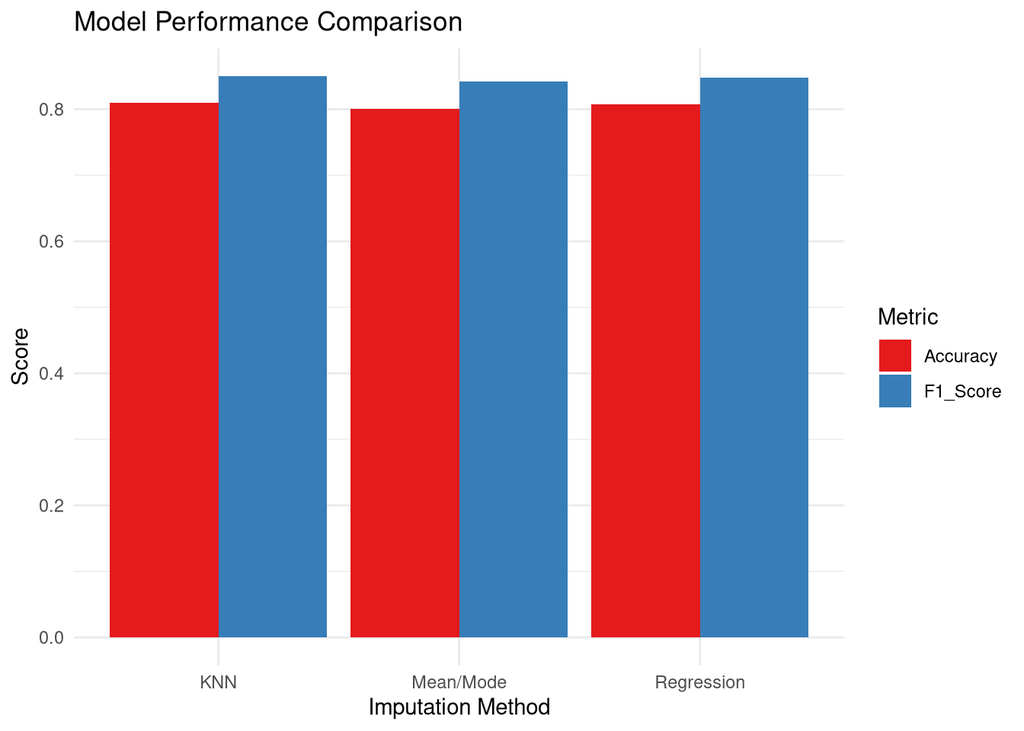

```r
library(ggplot2)
library(tidyr)

# Prepare data
results <- data.frame(
  Method = c("Mean/Mode", "Regression", "KNN"),
  Accuracy = c(0.801, 0.808, 0.810),
  F1_Score = c(conf_matrix_mean$byClass['F1'],
               conf_matrix_reg$byClass['F1'],
               conf_matrix_knn$byClass['F1'])
) %>% pivot_longer(-Method, names_to = "Metric")

# Plot
ggplot(results, aes(Method, value, fill = Metric)) +
  geom_col(position = "dodge") +
  labs(title = "Model Performance Comparison",
       y = "Score", x = "Imputation Method") +
  scale_fill_brewer(palette = "Set1") +
  theme_minimal()
```

This comparison shows how different methods for handling missing data affect our model’s predictions:

KNN imputation works best (0.81 accuracy), preserving complex patterns in the data.

Regression comes close (0.808 accuracy), using statistical relationships to fill gaps.

Simple mean/mode replacement performs worst (0.801 accuracy), as averages can’t capture real-world variability.

The F1-scores (0.85 for KNN) confirm this ranking, especially important since our survival data is imbalanced.”

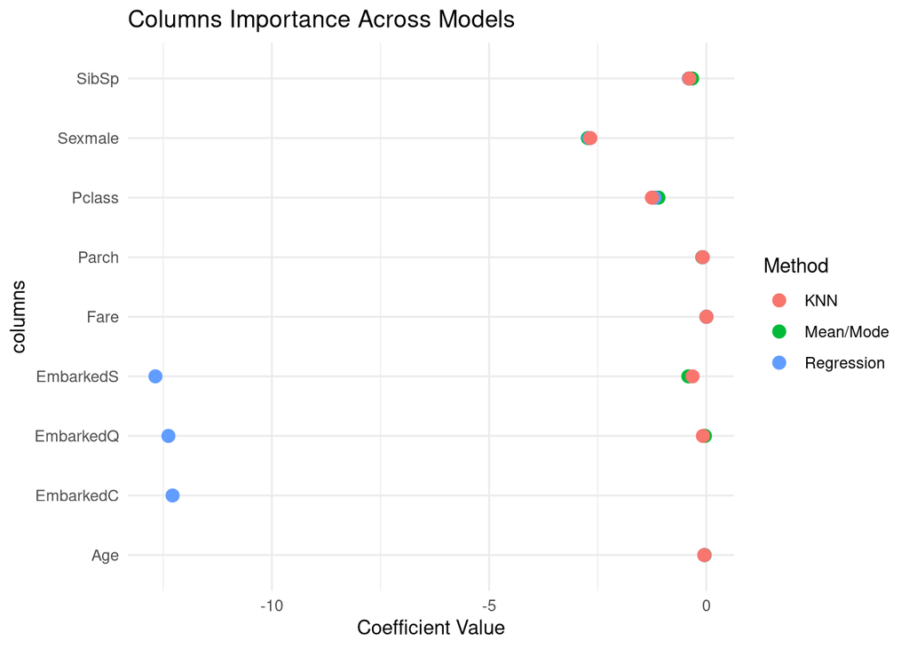

```r
library(dplyr)
library(broom)
library(ggplot2)

# Get coefficients from each model
coef_mean <- tidy(logit_mean) %>% mutate(Method = "Mean/Mode")
coef_reg <- tidy(logit_reg) %>% mutate(Method = "Regression")
coef_knn <- tidy(logit_knn) %>% mutate(Method = "KNN")

# Combine all coefficients
coefs <- rbind(coef_mean, coef_reg, coef_knn)

# Plot (simple version)
ggplot(coefs %>% filter(term != "(Intercept)"),
       aes(x = term, y = estimate, color = Method)) +
  geom_point(size = 3) +
  coord_flip() +
  labs(title = "Columns Importance Across Models",
       x = "columns",
       y = "Coefficient Value") +
  theme_minimal()
```

### Conclusion

Objective Achieved: Successfully compared three imputation methods (Mean/Mode, Regression, KNN) for handling missing data in the Titanic dataset. Based on our imputation results, the missingness in the Titanic dataset is most likely Missing at Random (MAR). This conclusion is supported by the higher performance of KNN imputation (accuracy: 0.81, F1-score: 0.85) and regression imputation (accuracy: 0.808), compared to simple mean/mode imputation (accuracy: 0.801). These results suggest that the missing values are related to other observed variables, not completely random (MCAR) or dependent on unobserved data (MNAR).

##### Best Imputation Method:

KNN Imputation achieved the highest accuracy (81.0%) by intelligently filling missing values based on similar passengers.

Regression Imputation was a close second (80.8%), using statistical relationships.

Mean/Mode performed worst (80.1%), as it oversimplified the data.

##### Top Survival Influencers:

Gender (Sex_male) was the strongest predictor—being male drastically reduced survival chances.

Wealth (Fare and Pclass):

Higher fares improved survival.

Lower-class passengers (3rd class) had significantly worse outcomes.

#### Implications

For Data Quality:

Use KNN/Regression for accurate models—they preserve real patterns. Avoid mean imputation for critical tasks.

For Predictive Modeling:

Mean imputation’s distortion of age/class relationships could hide socioeconomic biases. Advanced methods (KNN) mitigate this.

#### Limitations

Computational Cost: KNN is slower than regression/mean—may not suit huge datasets.

Assumptions: Regression assumes linear relationships; KNN assumes similar neighbors exist.

Generalizability: Results are specific to the Titanic dataset. Test on other datasets to confirm trends.

#### Final Recommendation

“For reliable predictions, use KNN imputation and prioritize gender/class/wealth features. Mean imputation is only for quick drafts. Always check how missing data handling affects your model’s fairness and accuracy.”

## References

Afkanpour, Marziyeh, Elham Hosseinzadeh, and Hamed Tabesh. 2024. “Identify the Most Appropriate Imputation Method for Handling Missing Values in Clinical Structured Datasets: A Systematic Review.” *BMC Medical Research Methodology* 24 (1): 188.

Alwateer, Majed, El-Sayed Atlam, Mahmoud Mohammed Abd El-Raouf, Osama A Ghoneim, and Ibrahim Gad. 2024. “Missing Data Imputation: A Comprehensive Review.” *Journal of Computer and Communications* 12 (11): 53–75.

Durrant, Gabriele B et al. 2005. “Imputation Methods for Handling Item-Nonresponse in the Social Sciences: A Methodological Review.” *ESRC National Centre for Research Methods and Southampton Statistical Sciences Research Institute. NCRM Methods Review Papers NCRM/002*.

Farhangfar, Alireza, Lukasz A Kurgan, and Witold Pedrycz. 2007. “A Novel Framework for Imputation of Missing Values in Databases.” *IEEE Transactions on Systems, Man, and Cybernetics-Part A: Systems and Humans* 37 (5): 692–709.

Karim, Md. Rezaul, and Md. Saiful Islam. 2024. “Missing Data Imputation: A Comprehensive Review.” *Scirp Journal of Data Science* 21: 99–115. https://doi.org/10.4236/jds.2024.210008.

Lee, Sunghee, and Trivellore E. Raghunathan. 2024. “The Prevention and Handling of the Missing Data.” *Journal of Epidemiological Methods* 19: 45–62. https://doi.org/10.1016/j.jem.2024.02.003.

Little, Roderick JA, and Donald B Rubin. 2019. *Statistical Analysis with Missing Data*. Vol. 793. John Wiley & Sons.

Pedersen, Alma B, Ellen M Mikkelsen, Deirdre Cronin-Fenton, Nickolaj R Kristensen, Tra My Pham, Lars Pedersen, and Irene Petersen. 2017. “Missing Data and Multiple Imputation in Clinical Epidemiological Research.” *Clinical Epidemiology*, 157–66.

Salgado, Cátia M, Carlos Azevedo, Hugo Proença, and Susana M Vieira. 2016. “Missing Data.” *Secondary Analysis of Electronic Health Records*, 143–62.

Stekhoven, Daniel J, and Peter Bühlmann. 2012. “MissForest—Non-Parametric Missing Value Imputation for Mixed-Type Data.” *Bioinformatics* 28 (1): 112–18.

Sterne, Jonathan AC, Ian R White, John B Carlin, Michael Spratt, Patrick Royston, Michael G Kenward, Angela M Wood, and James R Carpenter. 2009. “Multiple Imputation for Missing Data in Epidemiological and Clinical Research: Potential and Pitfalls.” *Bmj* 338.

Yadav, Subhash Kumar, Gajendra K Vishwakarma, and Dinesh K Sharma. 2024. “A Computational Strategy for Estimation of Mean Using Optimal Imputation in Presence of Missing Observation.” *Scientific Reports* 14 (1): 6433.